# Pitchfork 1999 to 2017 Reviews Analysis

Daniel Rolando Quintanilla Treviño

3/9/2021

## Introduction

In this report we will analyze a dataset containing every review that the music publication Pitchfork has released from January 1999 to December 2017. The objective of this analysis will be to get insights into Pitchfork critics’ preferences, as well as the trends in reviews through the years.

First we create a data frame with the data from the .csv file.

```r
df <- read.csv("p4kreviews.csv")
```

We take a glimpse at the structure of the data frame.

```r
head(df)
```

```
##   X                 album                           artist best            date
## 1 1      A.M./Being There                            Wilco    1 December 6 2017
## 2 2              No Shame                           Hopsin    0 December 6 2017
## 3 3      Material Control                         Glassjaw    0 December 6 2017
## 4 4 Weighing of the Heart                    Nabihah Iqbal    0 December 6 2017
## 5 5           The Visitor Neil Young / Promise of the Real    0 December 5 2017
## 6 6         Perfect Angel                  Minnie Riperton    1 December 5 2017
##     genre
## 1    Rock
## 2     Rap
## 3    Rock
## 4 Pop/R&B
## 5    Rock
## 6 Pop/R&B
##                                                                                                                                                                                                                                                                                                          …
## 1 Best new reissue 1 / 2 Albums Newly reissued and remastered, the group’s first two albums find Jeff Tweedy and his Chicago band transforming themselves from alt-country also-rans into a formidable rock‘n’roll outfit. The nuclear detonation of Uncle Tupelo launched an alt-country arms race, with…
## 2                                                                                                                                                                                                                                                                                                        …
## 3                                                                                                                                                                                                                                                                                                        …
## 4                                                                                                                                                                                                                                                                                                        …
## 5                                                                                                                                                                                                                                                                                                        …
## 6                                                                                                                                                                                                                                                                                                        …
##   score
## 1   7.0
## 2   3.5
## 3   6.6
## 4   7.7
## 5   6.7
## 6   9.0
```

- The “review” column contains a long paragraph of text extracted from the review. It can be useful to categorize review content, but it is hard to visualize properly in a table.

We take a look at the structure of the data frame.

```r
str(df)
```

```
## 'data.frame':    19555 obs. of  8 variables:
##  $ X     : int  1 2 3 4 5 6 7 8 9 10 ...
##  $ album : chr  "A.M./Being There" "No Shame" "Material Control" "Weighing of the Heart" ...
##  $ artist: chr  "Wilco" "Hopsin" "Glassjaw" "Nabihah Iqbal" ...
##  $ best  : int  1 0 0 0 0 1 0 0 0 0 ...
##  $ date  : chr  "December 6 2017" "December 6 2017" "December 6 2017" "December 6 2017" ...
##  $ genre : chr  "Rock" "Rap" "Rock" "Pop/R&B" ...
##  $ review: chr  "Best new reissue 1 / 2 Albums Newly reissued and remastered, the group’s first two albums find Jeff Tweedy and "| __truncated__ "On his corrosive fifth album, the rapper takes aim at several targets and whiffs spectacularly. His verbose, tr"| __truncated__ "On their first album i…
##  $ score : num  7 3.5 6.6 7.7 6.7 9 5.8 6.2 5.3 8.1 ...
```

What is the summary of the data?

```r
summary(df)
```

```
##        X            album              artist               best
##  Min.   :    1   Length:19555       Length:19555       Min.   :0.00000
##  1st Qu.: 4890   Class :character   Class :character   1st Qu.:0.00000
##  Median : 9778   Mode  :character   Mode  :character   Median :0.00000
##  Mean   : 9778                                         Mean   :0.05318
##  3rd Qu.:14666                                         3rd Qu.:0.00000
##  Max.   :19555                                         Max.   :1.00000
##      date              genre              review              score
##  Length:19555       Length:19555       Length:19555       Min.   : 0.000
##  Class :character   Class :character   Class :character   1st Qu.: 6.500
##  Mode  :character   Mode  :character   Mode  :character   Median : 7.300
##                                                           Mean   : 7.027
##                                                           3rd Qu.: 7.800
##                                                           Max.   :10.000
```

- The mean score of all the reviews is 7.03, and the median is 7.3.

The date of the review is a string type data instead of date. In order to properly analyze based on the date, we have to change it into the proper format.

```r
df <- df %>%
  separate(date, sep=" ", into = c("month", "day", "year")) %>%
  select(X, album, artist, best, year, month, day, genre, review, score)
```

Here is a visualization of the distribution of genres in the reviews.

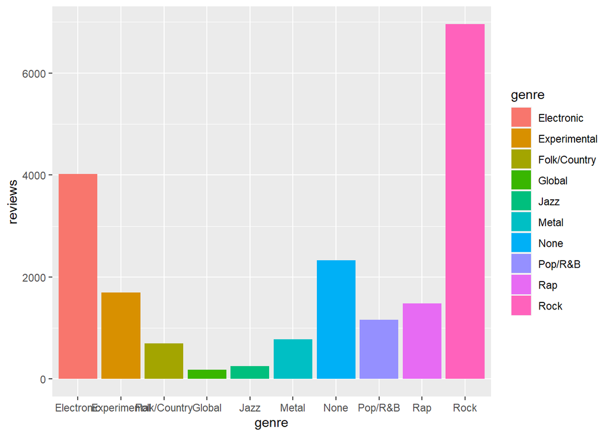

```r
df_genres <- df %>%
  group_by(genre) %>%
  count(genre, sort = FALSE, name = "reviews")

ggplot(df_genres, aes(x = genre, y = reviews, fill = genre)) + geom_col()
```

- We can identify that Rock is by far the most popular genre in Pitchfork reviews, with Electronic music in 2nd place and music without genre and Experimental music in 3rd place. 4th place is Rap and after it is Pop and R&B.

Here is a visualization of the reviews published by year:

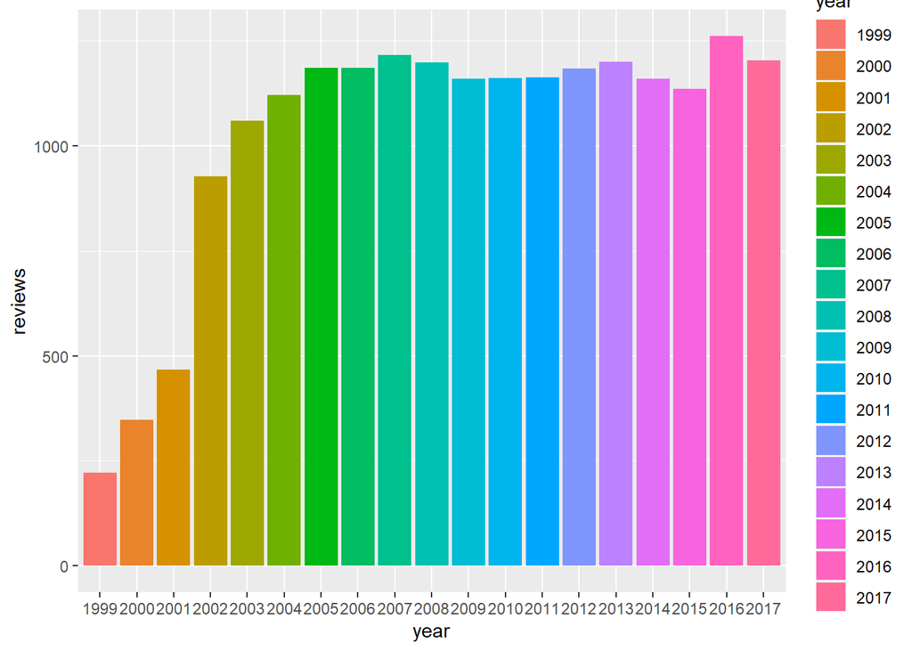

```r
df_year <- df %>%
  group_by(year) %>%
  count(year, sort = FALSE, name = "reviews")

ggplot(df_year, aes(x = year, y = reviews, fill = year)) + geom_col()
```

How are all review scores distributed? Let’s find out:

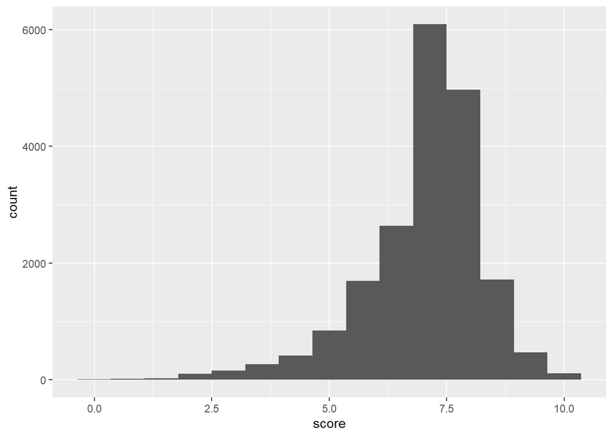

```r
ggplot(df, aes(x = score)) + geom_histogram(bins = 15)
```

## Developing questions, getting answers

Now that we know a bit more about the dataset we are working with, we can take what we learned to ask questions and gain insight. For each question, a graph will be developed to visualize the answer to that question.

### What are the top 10 most reviewed artists by Pitchfork in the 2010s?

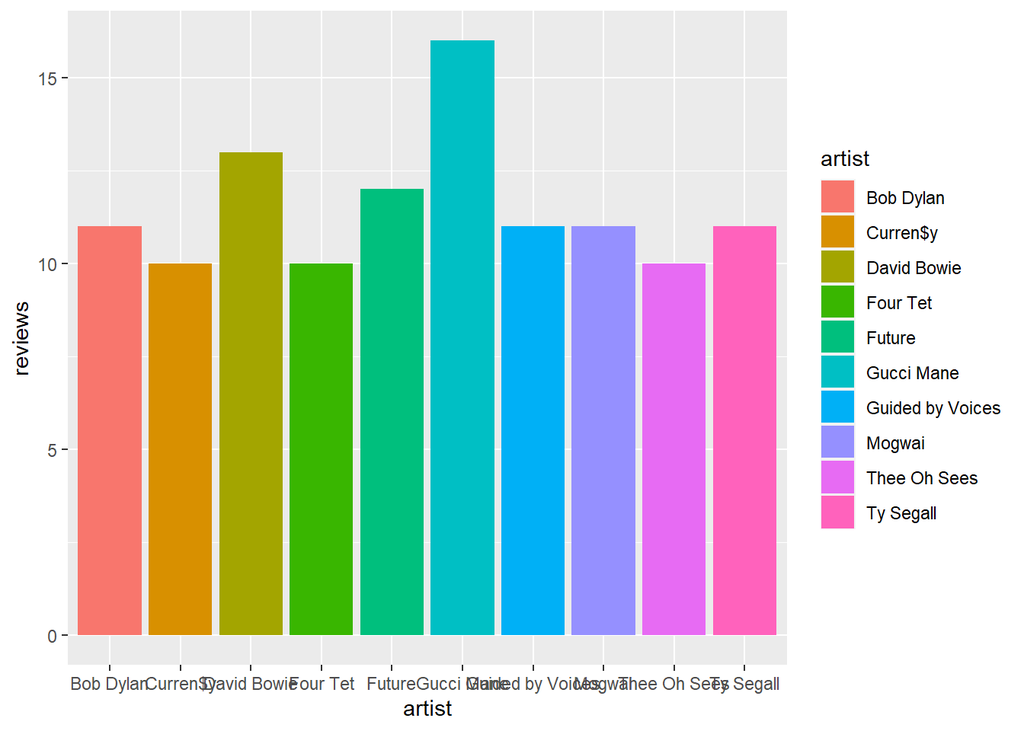

```r
df_top10artistbyyear <- df %>%
  filter(artist != "Various Artists", year >= 2010 & year <= 2017) %>%
  group_by(artist) %>%
  count(artist, sort = TRUE, name = "reviews") %>%
  head(10)

ggplot(df_top10artistbyyear, aes(x = artist, y = reviews, fill = artist)) + geom_col()
```

- The top 10 most reviewed artists in the 2010s were:
1. Gucci Mane
2. David Bowie
3. Future
4. Bob Dylan
5. Guided by Voices
6. Mogwai
7. Ty Segall
8. Curren$y
9. Four Tet
10. Thee Oh Sees

### How have the medium and median scores changed through the years?

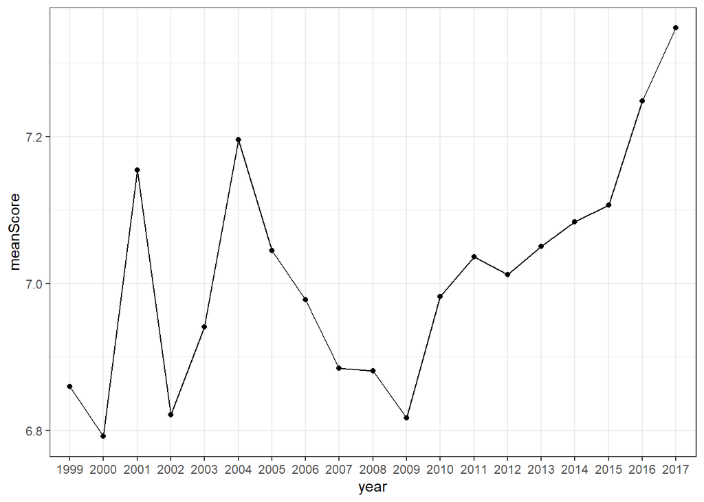

```r
df_scoresbyyear <- df %>%
  group_by(year) %>%
  summarize(
    meanScore = mean(score),
    medianScore = median(score)
  )

ggplot(df_scoresbyyear, aes(x = year, y = meanScore)) +
  geom_line(aes(group=1)) + geom_point() + theme_bw()
```

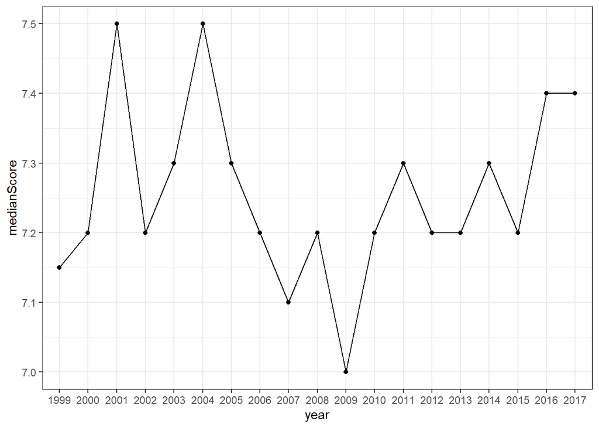

```r
ggplot(df_scoresbyyear, aes(x = year, y = medianScore)) +
  geom_line(aes(group=1)) + geom_point() + theme_bw()
```

### What is the average score of a Best New Album vs the average score of a non Best New Album?

```r
df_AvgBest <- df %>%
  group_by(best) %>%
  summarize(
    meanScore = mean(score)
  )
force(df_AvgBest)
```

```
## # A tibble: 2 x 2
##    best meanScore
## * <int>     <dbl>
## 1     0      6.93
## 2     1      8.68
```

- 1 means Best New Albums and 0 means regular album. The average score for Best New Music is 8.68, while regular music has an average of 6.93.

### How are scores distributed by genre? Which genre has the highest scores and which genre has the lowest?

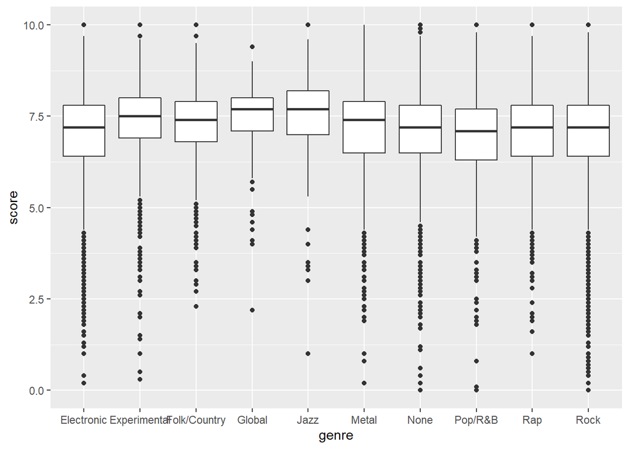

```r
ggplot(df, aes(x = genre, y = score)) + geom_boxplot()
```

### How are King Gizzard & The Lizard Wizard review scores distributed?

Man, I love King Gizz. In my opinion, the most prolific band of all time after The Beatles. Pitchfork kinda hates them from what I have heard… let’s see how their scores are distributed.

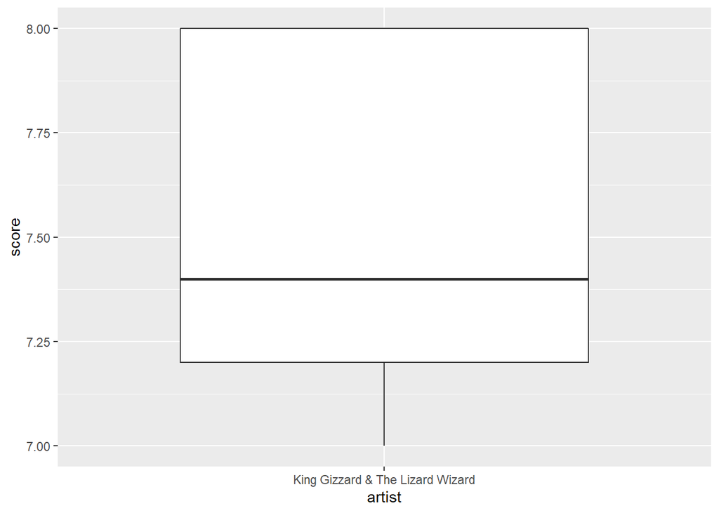

```r
df_KingGizz <- df %>%
  filter(artist == "King Gizzard & The Lizard Wizard") %>%
  arrange(desc(year))

ggplot(df_KingGizz, aes(x = artist, y = score)) + geom_boxplot()
```

### What are Pitchfork’s scores for the first three Tame Impala albums?

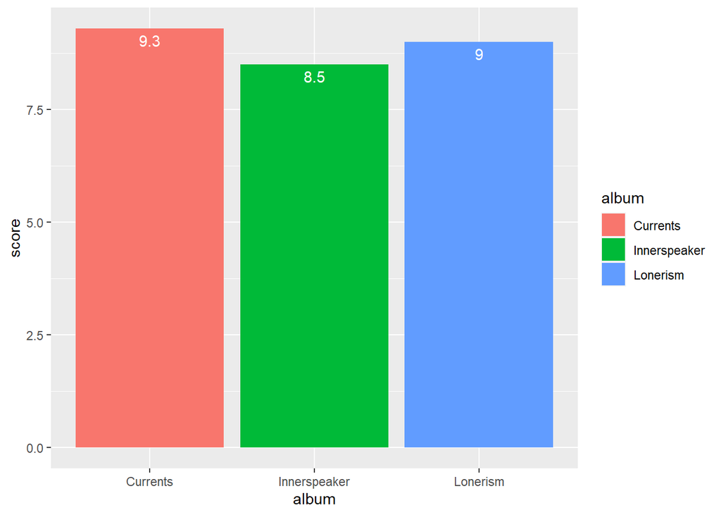

```r
df_TameImpala <- df %>%
  filter(artist == "Tame Impala")

ggplot(df_TameImpala, aes(x = album, y = score, fill = album)) + geom_col() + geom_text(aes(label = score), vjust = 1.5, colour = "white")
```

- 2015’s Currents is Pitchfork’s favorite Tame Impala album with a score of 9.3.
- 2012’s Lonerism is in second place with a score of 9.0.
- 2010’s Innerspeaker, the band’s debut, has a score of 8.5.
- It would seem that Pitchfork likes Tame Impala more and more with each release.